# Network Analytics - Assignment 1

#### David Wheatley (01633983)

#### 03 - May - 2020

# Question 1

## 1.1 - Part A

By definition a **Strongly connected, directed graph** requires there to be a directed path from every node to every other node in the graph. This may be achieved either with an edge directly linking the two nodes or with multiple edges passing through other nodes to form the path.

For a node to have **zero in-degree** there is no edge pointing to the node and thus it is impossible to have a path that terminates at this point.

Similarly, if a node has **zero out-degree** there is no edge leaving the node and therefore it is impossible for any path to originate from this node.

Furthermore, a node with both **zero in-degree** and **zero out-degree** is disconnected from the entire of the graph.

Given the above definitions are directly contradictory we can clearly state that "in a directed, strongly connected graph containing more than one node, no node can have a zero in-degree or zero out-degree.

## 1.2 - Part B

Starting from the definitions of a **tree** and a **bipartite graph** we can prove that every tree is a bipartite graph.

- A tree is a connected graph with no circuits / cycles. It therefore starts at one or many sources (with zero in-degree) and ends at one or many sinks (with zero out-degree).

[figure not shown]

- A bipartite graph - is a graph that can be partitioned into 2 disjoint subsets $V_1$ and $V_2$ such that no two nodes in the same set are adjacent.

The following process outline the steps to prove that every tree is a bipartite graph.

- We start by designating a node as a member of set $V_1$.
- All the children of this node are then placed in set $V_2$
- By definition, none of these children are adjacent their relationship is with the parent node
- We then place the children of the children (i.e. the grandchildren) into set $V_1$
- We then repeat this process alternating between $V_1$ and $V_2$ for every generation.

The resulting graph is bipartite as illustrated above.

## 1.3 - Part C

If a graph is acyclic by definition, there must be at least one sink node (zero out-degree) and at least 1 source node (zero in-degree). If, when the graph is converted to an undirected graph cycles exist the simple breadth first search algorithm is insufficient for performing a topological sort.

[figure not shown]

In this scenario, we need to calculate the shortest path both from the source to the node and from the node to the sink using a breadth first search algorithm.

For the above example we obtain:

Distance from the source to the node:

| Nodes | Distance |
| --- | --- |
| a,b | 0 |
| e,c,f,d,h | 1 |
| i,k,g,j | 2 |

Distance from node to the sink:

| Nodes | Distance |
| --- | --- |
| k | 0 |
| i,f,j | 1 |
| e,c,b,g,h | 2 |
| a,d | 3 |

We can then number the nodes by looking first at nodes with path length 0 from the source (a & b) We then sort these nodes in order of the longest distance to the source a=3, b=2 so we add 'a' to the list first and then 'b'. Which gives us the sequence [a,b]

This process is repeated for nodes with distance=1 from the source (e,c,f,d,h) and their respective distance from the sink. e=2, c=2, f=1, d=3, h=2. We then add these nodes to the list in descending order, giving us [a,b,d,e,c,h,f]

We repeat these steps for path length 2 (i,k,g,j) with distances from the sink of: i=1,k=0,g=2,j=1 and add them to the list in descending order giving us [a,b,d,e,c,h,f,g,i,j,k] where no node is preceded by one with a higher numerical value, as shown in the diagram below.

[figure not shown]

By following this method until we reach the end of the graph, we can always guarantee a topological sort can be achieved.

```python
#Import the required libraries
import numpy as np
import pandas as pd
import networkx as nx

%matplotlib inline
import matplotlib.pyplot as plt
import sys
```

# Question 2

## Introduction

This section details an approach to understanding the correlation between asset prices and provide an intuitive visual representation, that could help understand potential risk and exposure. The approach is based on a solution proposed by Julian West https://julian-west.github.io/blog/visualising-asset-price-correlations/

## 2.1 Import the CSV file into a dataframe

The first step to analyse the asset price movements is to load the CSV file into a pandas dataframe, allowing us to perform the necessary transforamtions, setting the 'Date' column as the index.

```python
#  Import the file
place_holder = "./"
asset_prices_df = pd.read_csv(place_holder + 'HW1_asset_prices.csv', index_col='Date')

# Check that the information has correctly copied across
print('Number of records = ' + str(len(asset_prices_df)))
asset_prices_df.head()
```

```
Number of records = 1013
```

| Date | EOD~BND.11 | EOD~DBC.11 | EOD~DIA.11 | EOD~EEM.11 | EOD~EFA.11 | EOD~EMB.11 | EOD~EPP.11 | EOD~EWG.11 | EOD~EWI.11 | EOD~EWJ.11 | ... | EOD~VGK.11 | EOD~VPL.11 | EOD~VXX.11 | EOD~XLB.11 | EOD~XLE.11 | EOD~XLF.11 | EOD~XLK.11 | EOD~XLU.11 | EOD~CSJ.11 | EOD~FXF.11 |
| --- | --- | --- | --- | --- | --- | --- | --- | --- | --- | --- | --- | --- | --- | --- | --- | --- | --- | --- | --- | --- | --- |
| 2017-11-08 | 81.83 | 16.40 | 235.46 | 46.78 | 69.87 | 114.60 | 47.69 | 33.18 | 30.95 | 60.02 | ... | 58.20 | 72.77 | 33.53 | 58.70 | 69.82 | 26.25 | 64.01 | 55.70 | 104.96 | 94.5100 |
| 2017-11-07 | 81.89 | 16.43 | 235.42 | 46.56 | 69.64 | 114.65 | 47.22 | 33.07 | 31.09 | 59.65 | ... | 58.17 | 72.20 | 33.52 | 58.64 | 70.16 | 26.38 | 63.66 | 55.66 | 105.01 | 94.5400 |
| 2017-11-06 | 81.86 | 16.53 | 235.41 | 46.86 | 69.90 | 115.26 | 47.20 | 33.34 | 31.22 | 59.18 | ... | 58.67 | 71.98 | 33.34 | 58.58 | 70.25 | 26.75 | 63.63 | 55.00 | 105.00 | 94.7500 |
| 2017-11-03 | 81.80 | 16.22 | 235.18 | 46.34 | 69.80 | 115.42 | 47.09 | 33.39 | 31.22 | 59.19 | ... | 58.58 | 71.88 | 33.66 | 58.83 | 68.68 | 26.78 | 63.49 | 55.21 | 105.00 | 94.4400 |
| 2017-11-02 | 81.73 | 16.12 | 234.96 | 46.58 | 69.91 | 116.15 | 47.31 | 33.50 | 31.43 | 59.05 | ... | 58.69 | 71.89 | 33.71 | 58.86 | 68.48 | 26.89 | 62.99 | 55.01 | 105.04 | 94.6299 |

5 rows × 39 columns

## 2.2 Convert asset prices into relative values

In order to understand the correlation of asset value movements we need to convert the absolute price values into a percentage change from the previous day.

To obtain the percentage change in asset price we subtract the log value of an asset from the log value of the previous day. Multiplying this number by 100 will then give us the percentage change. This is achieved using the '.diff' function from the pandas library. Given the dataframe is in descending date order we pass the parameter (-1) to subtract the previous day.

This process is then repeated for each asset using a for loop to populate the initially empty dataframe 'delta_percent_df'.

```python
#Create an empty dataframe
delta_percent_df = pd.DataFrame()

for column in asset_prices_df.columns:
    delta_percent_df[column] = np.log(asset_prices_df[column]).diff(-1)

# check the contents of the new dataframe
delta_percent_df.head()
```

| Date | EOD~BND.11 | EOD~DBC.11 | EOD~DIA.11 | EOD~EEM.11 | EOD~EFA.11 | EOD~EMB.11 | EOD~EPP.11 | EOD~EWG.11 | EOD~EWI.11 | EOD~EWJ.11 | ... | EOD~VGK.11 | EOD~VPL.11 | EOD~VXX.11 | EOD~XLB.11 | EOD~XLE.11 | EOD~XLF.11 | EOD~XLK.11 | EOD~XLU.11 | EOD~CSJ.11 | EOD~FXF.11 |
| --- | --- | --- | --- | --- | --- | --- | --- | --- | --- | --- | --- | --- | --- | --- | --- | --- | --- | --- | --- | --- | --- |
| 2017-11-08 | -0.000733 | -0.001828 | 0.000170 | 0.004714 | 0.003297 | -0.000436 | 0.009904 | 0.003321 | -0.004513 | 0.006184 | ... | 0.000516 | 0.007864 | 0.000298 | 0.001023 | -0.004858 | -0.004940 | 0.005483 | 0.000718 | -0.000476 | -0.000317 |
| 2017-11-07 | 0.000366 | -0.006068 | 0.000042 | -0.006423 | -0.003727 | -0.005306 | 0.000424 | -0.008131 | -0.004173 | 0.007911 | ... | -0.008559 | 0.003052 | 0.005384 | 0.001024 | -0.001282 | -0.013928 | 0.000471 | 0.011929 | 0.000095 | -0.002219 |
| 2017-11-06 | 0.000733 | 0.018932 | 0.000977 | 0.011159 | 0.001432 | -0.001387 | 0.002333 | -0.001499 | 0.000000 | -0.000169 | ... | 0.001535 | 0.001390 | -0.009552 | -0.004259 | 0.022602 | -0.001121 | 0.002203 | -0.003811 | 0.000000 | 0.003277 |
| 2017-11-03 | 0.000856 | 0.006184 | 0.000936 | -0.005166 | -0.001575 | -0.006305 | -0.004661 | -0.003289 | -0.006704 | 0.002368 | ... | -0.001876 | -0.000139 | -0.001484 | -0.000510 | 0.002916 | -0.004099 | 0.007906 | 0.003629 | -0.000381 | -0.002009 |
| 2017-11-02 | 0.000979 | 0.006223 | 0.003283 | 0.001289 | 0.003008 | 0.002759 | 0.005723 | 0.004488 | 0.009591 | 0.001186 | ... | 0.002559 | 0.002089 | -0.011210 | -0.007279 | -0.002916 | 0.009341 | 0.000476 | 0.003642 | 0.000000 | 0.004553 |

5 rows × 39 columns

## 2.3 Calculate correlations matrix

The next step is to create a correlations matrix use the pandas function '.corr()'

```python
correlation_matrix_df = delta_percent_df.corr()
# check the contents of the new correlation_matrix_df dataframe
correlation_matrix_df.head()
```

|  | EOD~BND.11 | EOD~DBC.11 | EOD~DIA.11 | EOD~EEM.11 | EOD~EFA.11 | EOD~EMB.11 | EOD~EPP.11 | EOD~EWG.11 | EOD~EWI.11 | EOD~EWJ.11 | ... | EOD~VGK.11 | EOD~VPL.11 | EOD~VXX.11 | EOD~XLB.11 | EOD~XLE.11 | EOD~XLF.11 | EOD~XLK.11 | EOD~XLU.11 | EOD~CSJ.11 | EOD~FXF.11 |
| --- | --- | --- | --- | --- | --- | --- | --- | --- | --- | --- | --- | --- | --- | --- | --- | --- | --- | --- | --- | --- | --- |
| EOD~BND.11 | 1.000000 | -0.086234 | -0.279161 | -0.069623 | -0.177521 | 0.296679 | -0.104739 | -0.188547 | -0.201014 | -0.159231 | ... | -0.181249 | -0.141707 | 0.222886 | -0.220603 | -0.198536 | -0.420264 | -0.197672 | 0.301774 | 0.598105 | 0.250142 |
| EOD~DBC.11 | -0.086234 | 1.000000 | 0.305137 | 0.428909 | 0.369637 | 0.313791 | 0.400316 | 0.283711 | 0.331083 | 0.250509 | ... | 0.367019 | 0.341089 | -0.224835 | 0.429541 | 0.677430 | 0.257454 | 0.225463 | 0.089290 | 0.028872 | 0.042324 |
| EOD~DIA.11 | -0.279161 | 0.305137 | 1.000000 | 0.719260 | 0.793387 | 0.343817 | 0.688344 | 0.722882 | 0.666315 | 0.691672 | ... | 0.765251 | 0.769604 | -0.797538 | 0.817422 | 0.655544 | 0.874902 | 0.849271 | 0.395247 | -0.042967 | -0.172730 |
| EOD~EEM.11 | -0.069623 | 0.428909 | 0.719260 | 1.000000 | 0.796425 | 0.580454 | 0.815049 | 0.697222 | 0.660268 | 0.638955 | ... | 0.763111 | 0.811155 | -0.668680 | 0.674630 | 0.607172 | 0.606749 | 0.686458 | 0.365031 | 0.123624 | -0.018461 |
| EOD~EFA.11 | -0.177521 | 0.369637 | 0.793387 | 0.796425 | 1.000000 | 0.466883 | 0.790699 | 0.884385 | 0.830052 | 0.785198 | ... | 0.949368 | 0.872972 | -0.721559 | 0.720030 | 0.610561 | 0.711714 | 0.725415 | 0.352270 | 0.050121 | 0.021760 |

5 rows × 39 columns

## 2.4 Create edge list

A weighted graph edge list can then be produced by reshaping the correlation matrix using the .stack() function, taking care to reset the index and remove any self correlations as these will always be 1.

```python
#convert matrix to list of edges and rename the columns
edges = correlation_matrix_df.stack().reset_index()
edges.columns = ['A','B','weight']

#remove self correlations
edges = edges.loc[edges['A'] != edges['B']].copy()

#show the first 5 rows of the edge list dataframe.
edges.head()
```

|  | A | B | weight |
| --- | --- | --- | --- |
| 1 | EOD~BND.11 | EOD~DBC.11 | -0.086234 |
| 2 | EOD~BND.11 | EOD~DIA.11 | -0.279161 |
| 3 | EOD~BND.11 | EOD~EEM.11 | -0.069623 |
| 4 | EOD~BND.11 | EOD~EFA.11 | -0.177521 |
| 5 | EOD~BND.11 | EOD~EMB.11 | 0.296679 |

## 2.5 Create graph from edge list

The above edge list is then converted into an undirected graph using NetworkX with the weights indicating the strength of the relationship.

```python
#Create undirected graph with weights corresponding to the correlation magnitude
G_asset = nx.from_pandas_edgelist(edges, 'A', 'B', edge_attr=['weight'])

#print out the graph info
print(nx.info(G_asset))
```

```
Name:
Type: Graph
Number of nodes: 39
Number of edges: 741
Average degree:  38.0000
```

## 2.6 Initial visualisation

Visualising the graph shows that all 39 nodes are connected and therefore little insight can be derived.

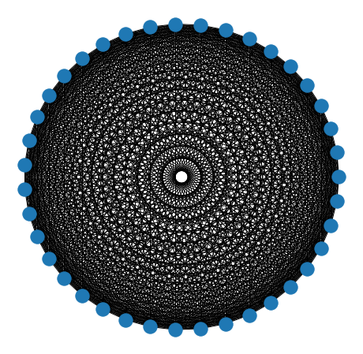

```python
plt.subplots(figsize=(8,8))
nx.draw_circular(G_asset)
plt.show()
```

## 2.7 Establish threshold

The correlation value describes the strength of the linear relationships between the assets. A meaningful relationship is demonstrated by larger absolute values from 1 showing the assets track perfectly, to -1 showing the asset price movements mirror each other. We therefore discount all correlations where the absolute value is below a set threshold.

```python
# set minium correlation threshold
threshold = 0.5

# create a new graph from edge list
G_threshold = nx.from_pandas_edgelist(edges, 'A', 'B', edge_attr=['weight'])

# create a list to store edges to remove
remove = []

# loop through edges in G_threshold to populate the remove list
for A, B in G_threshold.edges():
    correlation = G_threshold[A][B]['weight']
    #add to remove node list if abs(correlation) < threshold
    if abs(correlation) < threshold:
        remove.append((A, B))

# remove edges contained in the remove list
G_threshold.remove_edges_from(remove)

print(str(len(remove)) + " edges removed")
```

```
530 edges removed
```

Having removed the edges that represent a weak correlation the graph can be redrawn

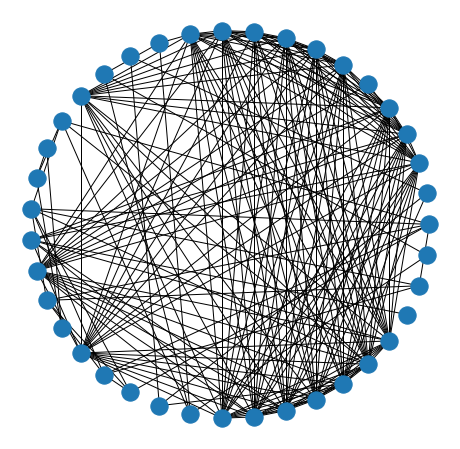

```python
plt.subplots(figsize=(8,8))
nx.draw_circular(G_threshold)
plt.show()
```

## 2.8 Investigate alternative graph layouts

Having established a meaningful graph we can investigate 4 standard graph layouts available in the NetworkX library.

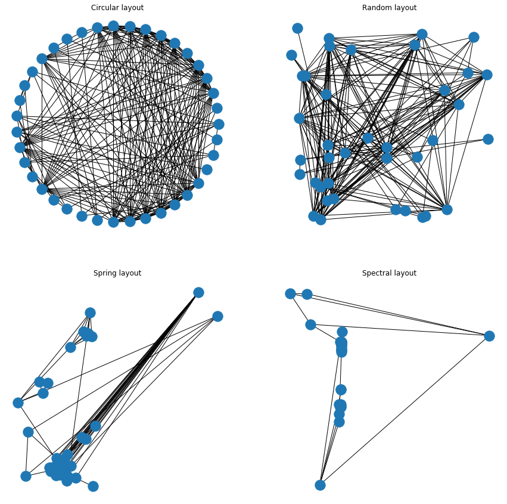

```python
fig, ax = plt.subplots(nrows=2, ncols=2,figsize=(15,15))

nx.draw(G_threshold, pos=nx.circular_layout(G_threshold),ax=ax[0,0])
ax[0,0].set_title("Circular layout")

nx.draw(G_threshold, pos=nx.random_layout(G_threshold),ax=ax[0,1])
ax[0,1].set_title("Random layout")

nx.draw(G_threshold, pos=nx.spring_layout(G_threshold),ax=ax[1,0])
ax[1,0].set_title("Spring layout")

nx.draw(G_threshold, pos=nx.spectral_layout(G_threshold),ax=ax[1,1])
ax[1,1].set_title("Spectral layout")

plt.show()
```

Looking at the above we conclude that the circle layout is the simplest to interpret. The main motivation is the spacing of the nodes allows individual nodes to be clearly identified. Given the relatively large number of nodes the spring and spectral layouts tend to overlay the nodes which will make labelling and identification of nodes difficult.

While the random layout spaces the nodes out adequately, the limitation of this plot is our ability to identify the nodes with high connectivity, and thus exhibit high levels of correlation.

The Circular plot satisfies our requirement to both separate the nodes, for identification, and easily identify the degree of each and is therefore our chosen solution.

## 2.9 Use of colour, weight and size properties to add meaning

Having selected our preferred graph type we now wish to use the NetworkX capability of formatting the nodes and edges to provide additional meaning and clarification. Here we will use:

- Labels to identify which assets the nodes correspond to
- Node size to represent how connected the assets is with other nodes in the network
- Edge colour to signify whether the correlations between assets are positive(green) or negative(red)
- Edge line weight the to represent the strength of the correlations between nodes

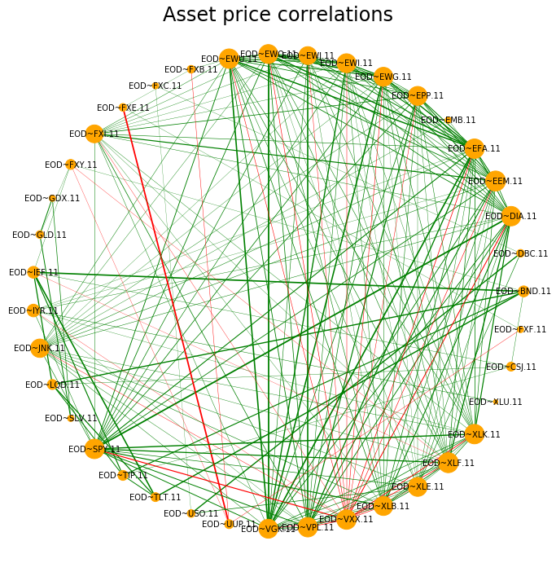

```python
def assign_colour(correlation):
    if correlation < 0:
        return 'red'
    else:
        return 'green'


def assign_weight(correlation):
    return 2 * abs(correlation)**3


def assign_size(degree):
    return degree * 30


# set weight and colour attributes based on correlation values
edge_colours = []
edge_width = []
for key, value in nx.get_edge_attributes(G_threshold, 'weight').items():
    edge_colours.append(assign_colour(value))
    edge_width.append(assign_weight(value))


# set node size based on degree
node_size = []
for key, value in dict(G_threshold.degree).items():
    node_size.append(assign_size(value))

plt.subplots(figsize=(12,12))

nx.draw(G_threshold, pos=nx.circular_layout(G_threshold), with_labels=True,
        node_size=node_size, node_color='orange', edge_color=edge_colours,
        width=edge_width,font_size=10)
plt.title("Asset price correlations", fontsize=24)
plt.show()
```

## 2.10 Conclusion

This final visualisation enables highly correlated assets, and the strength of this correlation to be easily identified Where this link is red it represents an opportunity to diversify, Where the edges are green it may represent increased exposure to market fluctuations. Small nodes indicate low levels of correlation and therefore may provide additional diversification opportunities.

# Question 3

This question has been answered in 2 parts.

- Section 3 cover the initial data processing / preparation
- Section 4 provides the requested analysis

## 3.1 Import the datasheets as dataframes

the first step in preparing the data is to load the datasheets into pandas dataframes and remove the 'NaN' values

```python
# The file name
place_holder = "./"
excelfile = place_holder +'HW2_who_talks_to_whom.xlsx'

# Import the 2 Excel sheets as dataframes
sent_df = pd.read_excel(excelfile, sheet_name = 'Sent', usecols = 'A:CD',index_col='Nodes')
received_df = pd.read_excel(excelfile, sheet_name = 'Received', usecols = 'A:CD',index_col='Nodes')

# Remove NaN values and replace with '-'
sent_df.replace({np.nan: '-'}, inplace = True)
received_df.replace({np.nan: '-'}, inplace = True)

# print the head of the files to check they loaded correctly
print('The top 5 rows of from the "Sent" datasheet\n')
print(sent_df.head())
print('\nThe top 5 rows of from the "Recieved" datasheet\n')
print(received_df.head())
```

```
The top 5 rows of from the "Sent" datasheet

      1  2  3  4  5  6  7  8  9  10  ... 72 73 74 75 76 77  78 79 80 81
Nodes                                ...
1      -  -  -  -  -  -  -  -  -  -  ...  -  -  -  1  -  5   1  1  5  2
2      2  -  -  1  3  -  5  -  -  -  ...  -  2  4  -  -  -   -  -  -  -
3      -  -  -  1  -  2  -  -  7  -  ...  5  -  -  -  3  -  11  2  2  -
4      -  -  1  -  1  -  -  -  -  1  ...  -  2  1  5  1  -   -  3  -  1
5      -  3  -  -  -  -  2  -  -  -  ...  -  2  3  -  -  3   -  -  -  -

[5 rows x 81 columns]

The top 5 rows of from the "Recieved" datasheet

      1  2  3  4  5  6  7  8  9  10  ... 72 73 74 75 76 77  78 79 80 81
Nodes                                ...
1      -  -  -  -  -  -  -  -  -  -  ...  -  -  -  1  -  5   1  1  5  2
2      2  -  -  1  3  -  5  -  -  -  ...  -  2  4  -  -  -   -  -  -  -
3      -  -  -  1  -  2  -  -  7  -  ...  5  -  -  -  3  -  11  2  2  -
4      -  -  1  -  1  -  -  -  -  1  ...  -  2  1  4  1  -   -  3  -  -
5      -  3  -  -  -  -  2  -  -  -  ...  -  2  3  -  -  3   -  -  -  -

[5 rows x 81 columns]
```

## 3.2 Combine the data frames

From preliminary inspection of the datasheets, in excel, we note that some inconsistencies between the number of emails reported as being sent and those received. Assuming any discrepancy is likely to be underreporting, due to lost or misreported group emails, the combined datasheet is populated by taking the maximum value from either data sheet.

```python
#Create a copy of the sent datframe as our combined value
combined_df = sent_df.copy()

#iterate over the table and where any mismatch is identified take the larger value
for x in range(1, 82):
    for y in range(1,82):
      if sent_df.loc[x,y] != received_df.loc[x,y]:
        if sent_df.loc[x,y] == '-':
          combined_df.at[x, y] = received_df.loc[x,y]
        elif received_df.loc[x,y] == '-':
          combined_df.at[x, y] = sent_df.loc[x,y]
        else:
          combined_df.at[x, y] = max(sent_df.loc[x,y], received_df.loc[x,y])

# Display the head of the file to check looking closely at row 4 column 75 to ensure it takes the larger value
print('The top 5 rows of from the "combined" datasheet\n')
print(combined_df.head())
```

```
The top 5 rows of from the "combined" datasheet

      1  2  3  4  5  6  7  8  9  10  ... 72 73 74 75 76 77  78 79 80 81
Nodes                                ...
1      -  -  -  -  -  -  -  -  -  -  ...  -  -  -  1  -  5   1  1  5  2
2      2  -  -  1  3  -  5  -  -  -  ...  -  2  4  -  -  -   -  -  -  -
3      -  -  -  1  -  2  -  -  7  -  ...  5  -  -  -  3  -  11  2  2  -
4      -  -  1  -  1  -  -  -  -  1  ...  -  2  1  5  1  -   -  3  -  1
5      -  3  -  -  -  -  2  -  -  -  ...  -  2  3  -  -  3   -  -  -  -

[5 rows x 81 columns]
```

## 3.3 Create a weighted edgelist

A weighted graph edge list is then produced by reshaping the combined dataframe using the .stack() function and removing all edges where no emails have been exchanged.

```python
# convert matrix to list of edges and rename the columns
edge_list = combined_df.stack().reset_index()
edge_list.columns = ['from','to','weight']

# remove self correlations (although non exist)
edge_list = edge_list.loc[edge_list['from'] != edge_list['to']].copy()

# remove all lines where no emails have been exchanged
edge_list = edge_list.drop(edge_list[edge_list.weight == '-'].index)

# print the dataframe head to ensure the information has been correctly prepared.
edge_list.head(5)
```

|  | from | to | weight |
| --- | --- | --- | --- |
| 12 | 1 | 13 | 1 |
| 13 | 1 | 14 | 5 |
| 17 | 1 | 18 | 2 |
| 21 | 1 | 22 | 3 |
| 24 | 1 | 25 | 2 |

## 3.4 Generate the network graph

The above edge list is then converted into an directed graph using NetworkX with the weights indicating the number of emails exchanged.

```python
# Using the NetworkX function create a directed graph from q3_edge list
G_who = nx.from_pandas_edgelist(edge_list, 'from', 'to', edge_attr=['weight'],create_using=nx.DiGraph())

# Print the basic graph information to check it makes sence
print(nx.info(G_who))
```

```
Name:
Type: DiGraph
Number of nodes: 81
Number of edges: 2055
Average in degree:  25.3704
Average out degree:  25.3704
```

## 3.5 Validate the graph using out-degree

To validate that the graph has been correctly generated the out degree can be calculated for each node and the maximum value reported, this can then be easily checked in Excel.

By calculating the normalised value we will also be able to validate the built-in functions utilised in section 3.6

```python
#Find out which node has the most out degree
max_out_deg = max([G_who.out_degree(n) for n in G_who.nodes()])
for n in G_who.nodes():
    if G_who.out_degree(n) == max_out_deg:
        prolific = n
print('Node ' + str(prolific) +' has sent emails to ' + str(max_out_deg) + ' people, which is the highest amongst the cohort')
print ('We can validate this inspecting the spreadsheet\n')

#Check the values are consistant once normalised.
normalised = max_out_deg/(len(G_who.nodes())-1)
print('When normalised this becomes: '+str(normalised))
```

```
Node 22 has sent emails to 49 people, which is the highest amongst the cohort
We can validate this inspecting the spreadsheet

When normalised this becomes: 0.6125
```

## 3.6 Calculate centrality measures using NetworkX built-in functions

Using the built-in functions we obtain 7 centrality measures, each of which produces a dictionary of results

- Keys represent the student number
- Values represent the centrality measure.

```python
#Calculate basic centrality measures
out_deg_cent = nx.out_degree_centrality(G_who)
in_deg_cent = nx.in_degree_centrality(G_who)
betweenness_centrality = nx.betweenness_centrality(G_who)
closeness_centrality = nx.closeness_centrality(G_who)

#Calculate spectral centrality measures
eigenvector_centrality = nx.eigenvector_centrality(G_who)
weighted_eigenvector_centrality = nx.eigenvector_centrality(G_who, weight='weight')
pagerank = nx.pagerank(G_who, alpha=0.9,weight='weight')

print('As in section 3.5 the normalised max out-degree is: ' + str( max(out_deg_cent.values())))
```

```
As in section 3.5 the normalised max out-degree is: 0.6125
```

Using the values in the above dictionaries the top ranking students by each measure can be calculated and reported in the table below.

```python
# set a variable to determine how many nodes to display
x = 5

top_outdeg = sorted(out_deg_cent, key=out_deg_cent.get, reverse=True)[:x]
top_indeg = sorted(in_deg_cent, key=in_deg_cent.get, reverse=True)[:x]
top_between = sorted(betweenness_centrality, key=betweenness_centrality.get, reverse=True)[:x]
top_close = sorted(closeness_centrality, key=closeness_centrality.get, reverse=True)[:x]

top_eigen = sorted(eigenvector_centrality, key=eigenvector_centrality.get, reverse=True)[:x]
top_w_eigen =sorted(weighted_eigenvector_centrality, key=weighted_eigenvector_centrality.get, reverse=True)[:x]
top_page = sorted(pagerank, key=pagerank.get, reverse=True)[:x]


top_df = pd.DataFrame(list(zip(top_indeg,top_outdeg, top_between, top_close,top_eigen,top_w_eigen,top_page)),
               columns =['In Degree', 'Out Degree','Betweeness', 'Closeness','Eigenvector','Weighted Eigenvector','PageRank'])
top_df
```

|  | In Degree | Out Degree | Betweeness | Closeness | Eigenvector | Weighted Eigenvector | PageRank |
| --- | --- | --- | --- | --- | --- | --- | --- |
| 0 | 32 | 22 | 32 | 32 | 78 | 19 | 45 |
| 1 | 14 | 32 | 22 | 14 | 22 | 69 | 22 |
| 2 | 53 | 47 | 62 | 53 | 40 | 12 | 18 |
| 3 | 62 | 62 | 26 | 62 | 31 | 39 | 49 |
| 4 | 22 | 42 | 4 | 40 | 62 | 60 | 32 |

# 4 - Organisational Network Analysis report

### 4.1 Introduction

Having imported the data from the spreadsheets and performed some preparatory transformations we can begin to identify the most influential members/leaders within the cohort.

To do this we will look at the distribution, and significant values, of 4 local centrality metrics:

- In-Degree
- Out-Degree
- Betweenness
- Closeness

We will then look at 3 spectral centrality measures to gain an understanding of global influence.

- Eigenvalue Centrality
- Weighted Eigenvalue Centrality
- Page Rank

After selecting the most appropriate measure a simplified network graph will be created to represent this information visually. Finally, we will look at the clustering co-efficient and endeavour to develop an improved strategy for controlling information flows by subdividing the total cohort into communities.

## 4.2 Investigate Centrality Distributions

The centrality measures help identify the individuals that are important in terms of their influence and importance for managing the overall flow of information across the cohort. While looking at the distributions of these metrics allow us to understand if this influence / control is spread evenly or consolidated in a few individuals.

The following charts show the centrality distributions and are discussed in detail below.

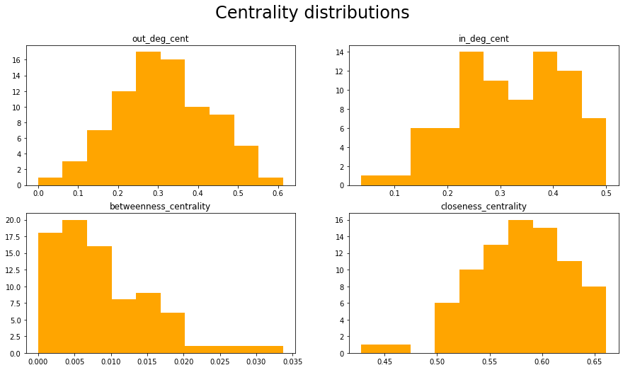

```python
# Create figure
fig, ax = plt.subplots(nrows=2, ncols=2,figsize=(15,8))
fig.suptitle('Centrality distributions', fontsize=24)


#Create plot of out_deg_cent distribution
ax[0,0].hist(list(out_deg_cent.values()),color='orange')
ax[0,0].set(title='out_deg_cent')

#Create plot of in_deg_cent distribution
ax[0,1].hist(list(in_deg_cent.values()),color='orange')
ax[0,1].set(title='in_deg_cent')

#Create plot of betweenness_centrality
ax[1,0].hist(list(betweenness_centrality.values()),color='orange')
ax[1,0].set(title='betweenness_centrality')

#Create plot of closeness distribution
ax[1,1].hist(list(closeness_centrality.values()),color='orange')
ax[1,1].set(title='closeness_centrality')

plt.show()
```

#### Degree Centrality (in-degree and out-degree)

The degree centrality shows how connected the student is to other members of the cohort, it doesn't reflect the quantity of emails being sent.

#### Betweenness Centrality

Betweenness centrality shows the individuals that influence the flow of information through the cohort by showing how often there are on the the shortest path between other students. Identifying these students is critical to ensuring any ideas / opinions are disseminated to disparate members of the cohort.

#### Closeness Centrality

Shows which students are best placed to influence the entire cohort, based on the shortest path between them and all other students. However the above distribution shows that this is a relatively tight group with little spread and therefore this measure contributes little in terms of identifying key members.

## 4.3 Investigate Spectral Centrality Distributions

Spectral Centrality measures can provide greater insight by placing value in the quality of the connections and not just the quantity of connections, distributions for which are shown below.

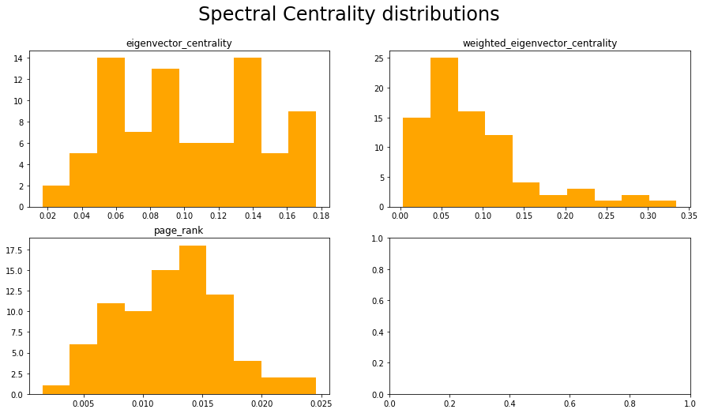

```python
# Create figure
fig, ax = plt.subplots(nrows=2, ncols=2,figsize=(15,8))
fig.suptitle('Spectral Centrality distributions', fontsize=24)

#Create plot of eigenvector_centrality distribution
ax[0,0].hist(list(eigenvector_centrality.values()),color='orange')
ax[0,0].set(title='eigenvector_centrality')

#Create plot of eigenvector_centrality distribution
ax[0,1].hist(list(weighted_eigenvector_centrality.values()),color='orange')
ax[0,1].set(title='weighted_eigenvector_centrality')

# Create pagerank distribution
ax[1,0].hist(list(pagerank.values()), color='orange')
ax[1,0].set(title='page_rank')

plt.show()
```

#### Weighted Eigen Centrality

Weighted Eigen Centrality builds on the previous metric by considering the volume of emails exchanged. The distribution shows a long tail with influence focussed on a few individuals.

#### Page Rank

PageRank is another variant of Eigen Centrality which also takes into account direction of the edge focussed on the recipient of the email.

## 4.4 Selecting the Leader in the Cohort

In selecting a leader, we are looking for an individual with influence over the total network and therefore the spectral measures provide the best initial indication. While PageRank works well for ranking the webpages it is of less value for emails where the onus is for a leader to transmit a message rather than for the recipient to find it. Similarly the weighted Eigen Centrality measure overly values the quantity of emails over the quality of emails and therefore presents a distorted view of influence.

Setting the variable 'Leader' = 78 in the code below shows that there is no direct connection between student 78 and student 32 (who has the highest betweenness score) which may limit the ability of 78 to influence the wider network. Therefore, in terms of selecting a leader we chose the next highest eigen centrality value which is student 22 which satisfy both criteria.

## 4.5 Draw the Graph

The first step to visualising the network is to generate a subgraph of the students directly connected to the selected leader.

```python
#Calculate the maximum eigen value
Leader = 22   #max(eigenvector_centrality, key=eigenvector_centrality.get)

print('The chosen leader is student:'+ str(Leader))
print('They have ' + str(len(list(G_who.neighbors(Leader))))+' neighbours')


Nodelist = list(G_who.neighbors(Leader))
Nodelist.append(Leader)
G_reduced = G_who.subgraph(Nodelist)
```

```
The chosen leader is student:22
They have 49 neighbours
```

We can then format the nodes and edges to present the information more clearly

- The leader node is shown in green
- Given the importance of betweenness, with regards to their ability to disseminate information to the wider cohort, these have been highlighted in red
- The size of each node represents the overall number of connections (degree)
- The weights of each edge represent the quantity of emails exchanged.
- Emails exchanged with the nominated leader are shown in green.

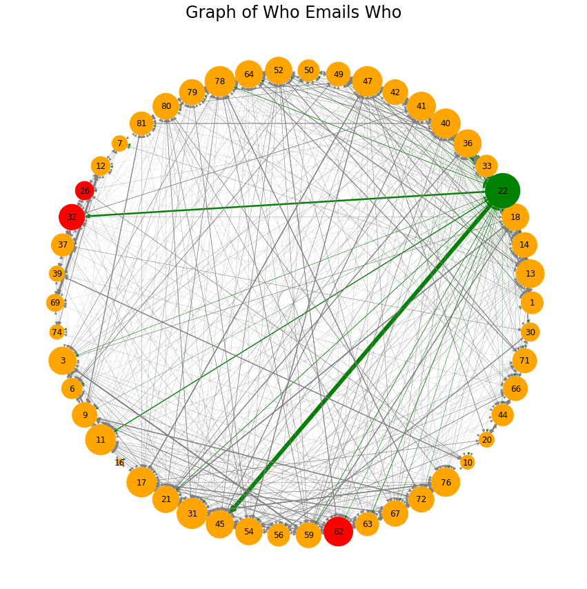

```python
def assign_colour(attribute):
    if Leader in (attribute):
        return 'green'
    else:
        return 'grey'

def assign_thickness(weight):
    return weight/20

def assign_node_size(degree):
    return degree * 30

def assign_node_color(node):
    if node == Leader:
        return 'green'
    elif node in top_between:
        return 'red'
    else:
        return 'orange'

# assign edge thickness depending on the volume of emails being exchanged
# set colour to green if the connection is with the leader
edge_colours = []
edge_width = []
for key, value in nx.get_edge_attributes(G_reduced, 'weight').items():
    edge_colours.append(assign_colour(key))
    edge_width.append(assign_thickness(value))

# assign node size depending on number of connections (degree)
node_size = []
for key, value in dict(G_reduced.degree).items():
    node_size.append(assign_node_size(value))


# assign node color depending on betweeness
node_color = []
for key, value in dict(G_reduced.degree).items():
    node_color.append(assign_node_color(key))


plt.subplots(figsize=(15,15))

nx.draw(G_reduced, pos=nx.circular_layout(G_reduced), with_labels=True,
        node_size=node_size, node_color=node_color, edge_color=edge_colours,
        width=edge_width)


plt.title("Graph of Who Emails Who", fontsize=24)
plt.show()
```

## 4.6 Clustering Co-efficient

The clustering co-efficient represents the tendency of the students to form tightly knit groups and enable the free exchange of ideas. While in the above analysis we identified the most influential student across the whole cohort, a more effective strategy could be to identify a number of leaders that represent a varierty of subgroups.

Below we show that the overall network is not strongly connected, which means that there is no direct link between all students and the global clustering coefficient is approximately 0.6

```python
print('Graph is weakly connected: '+ str(nx.is_weakly_connected(G_who)))
print('Graph is strongly connected: '+ str(nx.is_strongly_connected(G_who)))


# COnvert the graph into an undirected graph
G2 = G_who.to_undirected()

# Calculate the clustering coefficient of each node
cc2 = nx.clustering(G2)

# Calculate the global clustering coefficient
gcc2 = sum(list(cc2.values())) / len(G2.nodes())
print("Global clustering coefficient: ", gcc2)
```

```
Graph is weakly connected: True
Graph is strongly connected: False
Global clustering coefficient:  0.6077711931141129
```

## 4.7 Community detection

To partition the group into sub communities we can utilise the following code, the colour of each node represents each of the 5 groups.

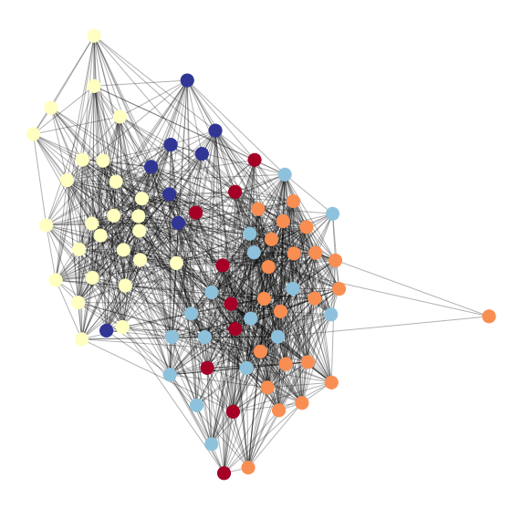

```python
# Improt the required library
import community
partition = community.best_partition(G2)
pos = nx.spring_layout(G2)
plt.figure(figsize=(10, 10))
plt.axis('off')
nx.draw_networkx_nodes(G2, pos, node_size=200, cmap=plt.cm.RdYlBu, node_color=list(partition.values()))
nx.draw_networkx_edges(G2, pos, alpha=0.3)
plt.show(G2)
```

## 4.8 Analysing the Community Clustering Coefficient

The following code then demonstrates that splitting the cohort into 5 communities the corresponding cluster coefficient increase from 0.6 to an average of 0.8 and therefore confirms our assumption that this would facilitate more efficient exchange of ideas.

```python
#Create a graph for each subcommunity
GroupA=[]
GroupB=[]
GroupC=[]
GroupD=[]
GroupE=[]

for k,v in partition.items():
    if v==0:
        GroupA.append(k)
    elif v==1:
        GroupB.append(k)
    elif v==2:
        GroupC.append(k)
    elif v==3:
        GroupD.append(k)
    elif v==4:
        GroupE.append(k)

# Create subgraphs for each group
GA= G_who.subgraph(GroupA)
GB= G_who.subgraph(GroupB)
GC= G_who.subgraph(GroupC)
GD= G_who.subgraph(GroupD)
GE= G_who.subgraph(GroupE)
```

```python
# calculate the clustering coefficents of each sub group
ccA = nx.clustering(GA)
ccB = nx.clustering(GB)
ccC = nx.clustering(GC)
ccD = nx.clustering(GD)
ccE = nx.clustering(GE)

gccA = sum(list(ccA.values())) / len(GA)
gccB = sum(list(ccB.values())) / len(GB)
gccC = sum(list(ccC.values())) / len(GC)
gccD = sum(list(ccD.values())) / len(GD)
gccE = sum(list(ccE.values())) / len(GE)

# / node_num


print("Global clustering coefficient A: ", gccA)
print("Global clustering coefficient B: ", gccB)
print("Global clustering coefficient C: ", gccC)
print("Global clustering coefficient D: ", gccD)
print("Global clustering coefficient E: ", gccE)
```

```
Global clustering coefficient A:  0.8697811447811448
Global clustering coefficient B:  0.8033098310616292
Global clustering coefficient C:  0.7314673067913608
Global clustering coefficient D:  0.7565434970947867
Global clustering coefficient E:  0.9384920634920636
```